# warmup04-adele-shen

```r
library(ggplot2)
library(dplyr)
library("readr")
```

## 1) Importing Data

```r
github <- 'https://raw.githubusercontent.com/ucb-stat133/stat133-hws/'
repo <- 'master/data/nba2018-players.csv'
datafile <- paste0(github, repo)
destination = "nba.data"
download.file(datafile, destination)
```

```r
# column_types = cols("character", "character", "factor", "integer", "integer", "integer", "integer", "character", "real", "integer", "integer", "integer", "integer", "integer", "integer")

# you can use a compact string representation where each character represents one column: c = character, i = integer, n = number, d = double, l = logical, f = factor, D = date, T = date time, t = time, ? = guess, or _/- to skip the column
```

```r
column_types = 'ccfiiiicdiiiiii'
```

```r
dat = read_csv("nba.data", col_types = column_types)
dat
```

```
## # A tibble: 477 x 15
##    player team  position height weight   age experience college salary
##    <chr>  <chr> <fct>     <int>  <int> <int>      <int> <chr>    <dbl>
##  1 Al Ho… BOS   C            82    245    30          9 Univer… 2.65e7
##  2 Amir … BOS   PF           81    240    29         11 <NA>    1.20e7
##  3 Avery… BOS   SG           74    180    26          6 Univer… 8.27e6
##  4 Demet… BOS   PG           73    201    22          0 Univer… 1.45e6
##  5 Geral… BOS   SF           79    205    31          9 <NA>    1.41e6
##  6 Isaia… BOS   PG           69    185    27          5 Univer… 6.59e6
##  7 Jae C… BOS   SF           78    235    26          4 Marque… 6.29e6
##  8 James… BOS   SG           78    215    21          2 Univer… 1.83e6
##  9 Jayle… BOS   SF           79    225    20          0 Univer… 4.74e6
## 10 Jonas… BOS   PF           82    231    29          6 <NA>    5.00e6
## # … with 467 more rows, and 6 more variables: games <int>, minutes <int>,
## #   points <int>, points3 <int>, points2 <int>, points1 <int>
```

```r
summary(dat)
```

```
##     player              team           position     height
##  Length:477         Length:477         C : 97   Min.   :69.00
##  Class :character   Class :character   PF: 98   1st Qu.:77.00
##  Mode  :character   Mode  :character   SG:102   Median :79.00
##                                        PG: 96   Mean   :79.09
##                                        SF: 84   3rd Qu.:82.00
##                                                 Max.   :87.00
##      weight           age          experience       college
##  Min.   :150.0   Min.   :19.00   Min.   : 0.000   Length:477
##  1st Qu.:200.0   1st Qu.:23.00   1st Qu.: 1.000   Class :character
##  Median :220.0   Median :26.00   Median : 4.000   Mode  :character
##  Mean   :219.9   Mean   :26.39   Mean   : 4.662
##  3rd Qu.:240.0   3rd Qu.:29.00   3rd Qu.: 7.000
##  Max.   :290.0   Max.   :40.00   Max.   :18.000
##      salary             games          minutes         points
##  Min.   :    5145   Min.   : 1.00   Min.   :   1   Min.   :   0.0
##  1st Qu.: 1050961   1st Qu.:25.00   1st Qu.: 381   1st Qu.: 124.0
##  Median : 3000000   Median :60.00   Median :1123   Median : 403.0
##  Mean   : 5804697   Mean   :50.71   Mean   :1164   Mean   : 510.3
##  3rd Qu.: 8269663   3rd Qu.:74.00   3rd Qu.:1843   3rd Qu.: 756.0
##  Max.   :30963450   Max.   :82.00   Max.   :3048   Max.   :2558.0
##     points3         points2         points1
##  Min.   :  0.0   Min.   :  0.0   Min.   :  0.00
##  1st Qu.:  2.0   1st Qu.: 30.0   1st Qu.: 15.00
##  Median : 26.0   Median :100.0   Median : 50.00
##  Mean   : 46.4   Mean   :142.3   Mean   : 86.49
##  3rd Qu.: 73.0   3rd Qu.:208.0   3rd Qu.:116.00
##  Max.   :324.0   Max.   :730.0   Max.   :746.00
```

```r
class(dat)
```

```
## [1] "spec_tbl_df" "tbl_df"      "tbl"         "data.frame"
```

## 2) Technical Questions about “readr”

###### a) When you print dat— typing the name of the object to see how it gets displayed— R tells you that it is a tibble. Do some research (e.g. google it) to explain what are the similarities and differences between a data.frame and a tibble.

##### The similarities between a data.frame and a tibble are that they are both tables of data that can be non-atomic. There are two main differences: printing and subsetting. Printing tibbles shows only the first 10 rows and all the columns that fit on screen. Each column reports name and type. Tibbles also clearly delineate [ and [[: [ always returns another tibble, [[ always returns a vector. (Source: https://blog.rstudio.com/2016/03/24/tibble-1-0-0/)

###### b) Say you want to import just a couple of columns from nba2018-players.csv. For instance, suppose you want to import columns player, team, salary, and points, with data types “character”, “character”, “double”, and “double”, respectively. Is it possible to use read_csv() to import only these columns, with the specified data types? Yes or No, and explain.

##### Yes. Use _/- to skip the column.

###### c) The base R function read.csv() uses arguments like header, col.names, na.strings, and colClasses. What are the equivalent (or similar) arguments in read_csv()?

##### For header = TRUE, use col_names = TRUE to use first row as column names. For col.names, there is col_names. For na.strings, there is na. For colClasses, there is col_types.

## 3) Salaries By Team

### a

```r
unique(dat$team)
```

```
##  [1] "BOS" "CLE" "TOR" "WAS" "ATL" "MIL" "IND" "CHI" "MIA" "DET" "CHO"
## [12] "NYK" "ORL" "PHI" "BRK" "GSW" "SAS" "HOU" "LAC" "UTA" "OKC" "MEM"
## [23] "POR" "DEN" "NOP" "DAL" "SAC" "MIN" "LAL" "PHO"
```

```r
team_salaries = summarise(
  group_by(dat, team),
  total_salary = sum(salary)/1000000,
  mean_salary = mean(salary)/1000000,
  median_salary = median(salary)/100000
)
team_salaries = arrange(team_salaries, desc(total_salary))
team_salaries
```

```
## # A tibble: 30 x 4
##    team  total_salary mean_salary median_salary
##    <chr>        <dbl>       <dbl>         <dbl>
##  1 CLE           127.        7.07          20.3
##  2 LAC           115.        7.65          35
##  3 MEM           109.        6.81          31.2
##  4 TOR           108.        7.23          53
##  5 SAS           105.        6.59          22.2
##  6 MIL           105.        5.51          25.7
##  7 ORL           104.        5.78          41.3
##  8 DET           103.        6.87          46.2
##  9 POR           102.        7.88          66.7
## 10 WAS           101.        6.72          37.3
## # … with 20 more rows
```

### b

```r
team_salaries_full = as.data.frame(team_salaries)
```

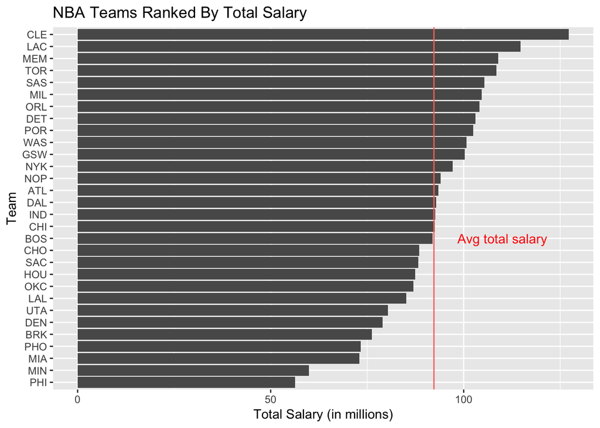

```r
ggplot(team_salaries_full, aes(x=reorder(team, total_salary), y=total_salary)) +
  geom_bar(stat = 'identity') +
  coord_flip() +
  labs(title = "NBA Teams Ranked By Total Salary") +
  xlab("Team") +
  ylab("Total Salary (in millions)") +
  geom_hline(aes(yintercept = mean(team_salaries_full$total_salary), color = 'red'), show.legend = FALSE) +
  annotate("text", x = "BOS", y = 110, label = "Avg total salary", color = 'red')
```

## 4) Points by Team

### a

```r
team_points = summarise(
  group_by(dat, team),
  total_points = sum(points),
  mean_points = mean(points),
  median_points = median(points)
)

team_points = arrange(team_points, desc(total_points))
```

### b

```r
team_points_full = as.data.frame(team_points)
team_points_full
```

```
##    team total_points mean_points median_points
## 1   GSW         9491    593.1875         407.5
## 2   HOU         9065    647.5000         568.0
## 3   LAC         8911    594.0667         538.0
## 4   BOS         8857    590.4667         515.0
## 5   DEN         8783    516.6471         587.0
## 6   CLE         8770    487.2222         265.0
## 7   SAS         8637    539.8125         490.0
## 8   IND         8618    538.6250         370.5
## 9   MIN         8591    613.6429         348.0
## 10  WAS         8574    571.6000         330.0
## 11  MIL         8497    447.2105         392.0
## 12  PHO         8430    495.8824         419.0
## 13  MIA         8312    593.7143         518.0
## 14  DET         8309    553.9333         365.0
```

[output cut: 16 more lines]

### c

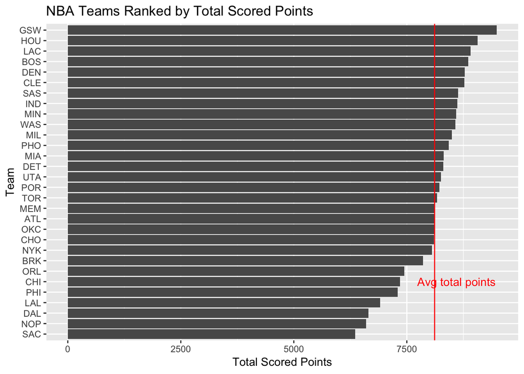

```r
ggplot(team_points_full) +
  geom_bar(aes(x = reorder(team, total_points), y = total_points), stat = 'identity') +
  labs(title = "NBA Teams Ranked by Total Scored Points") +
  xlab("Team") +
  ylab("Total Scored Points") +
  coord_flip() +
  geom_hline(yintercept = mean(team_points_full$total_points), color = 'red') +
  annotate(geom = "text", x = "CHI", y = 8600, label = "Avg total points", color = 'red')
```

```r
# Without stat ='identity' ggplot wants to aggregate your data into counts.
```

## 5) Cost of Scored Points

#### What is the team’s cost of a scored point (in terms of its payroll)?

### a

```r
points_salary = full_join(team_salaries, team_points, by = "team")
```

### b

```r
summary(points_salary)
```

```
##      team            total_salary     mean_salary    median_salary
##  Length:30          Min.   : 56.29   Min.   :3.311   Min.   : 9.452
##  Class :character   1st Qu.: 85.59   1st Qu.:5.390   1st Qu.:22.459
##  Mode  :character   Median : 92.72   Median :5.794   Median :31.280
##                     Mean   : 92.29   Mean   :5.846   Mean   :32.476
##                     3rd Qu.:102.93   3rd Qu.:6.559   3rd Qu.:40.181
##                     Max.   :127.25   Max.   :7.884   Max.   :66.667
##   total_points   mean_points    median_points
##  Min.   :6360   Min.   :369.5   Min.   :200.5
##  1st Qu.:7906   1st Qu.:463.7   1st Qu.:338.2
##  Median :8240   Median :527.0   Median :406.8
##  Mean   :8114   Mean   :515.6   Mean   :406.6
##  3rd Qu.:8611   3rd Qu.:567.2   3rd Qu.:463.5
##  Max.   :9491   Max.   :647.5   Max.   :587.0
```

### c

```r
points_salary1 = data.frame(mutate(points_salary, cost_point = total_salary*1000000/total_points))
```

### d

```r
summary(points_salary1$cost_point)
```

```
##    Min. 1st Qu.  Median    Mean 3rd Qu.    Max.
##    6970    9889   11901   11446   12807   14510
```

### e

```r
colors = c("blue", NA, NA, NA, NA, NA, NA, NA, NA, NA, NA, NA, NA, NA, NA, NA, NA, NA, NA, NA, NA, NA, NA, NA, NA, NA, NA, NA, NA, "red")
```

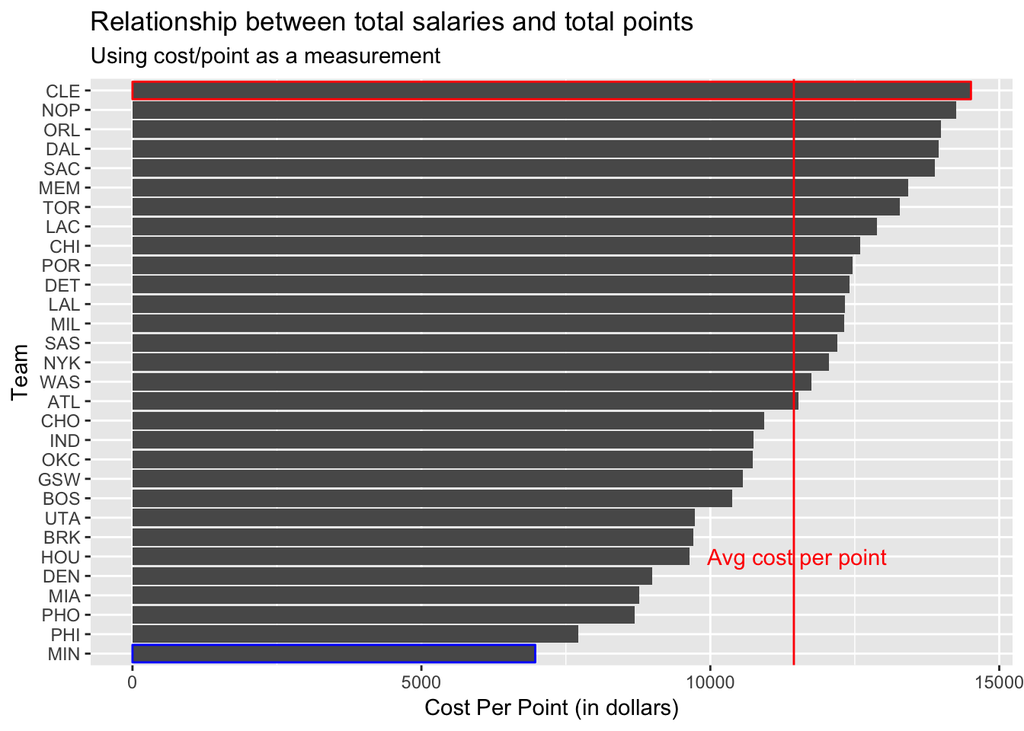

```r
ggplot(points_salary1) +
  geom_bar(aes(x=reorder(team, cost_point), y=cost_point), stat='identity', color = colors) +
  coord_flip() +
  labs(title = "Relationship between total salaries and total points", subtitle = "Using cost/point as a measurement") +
  xlab("Team") +
  ylab("Cost Per Point (in dollars)") +
  geom_hline(yintercept = mean(points_salary1$cost_point), color = 'red') +
  annotate(geom = "text", x = 6, y = 11500, label = "Avg cost per point", color = 'red')
```

### e

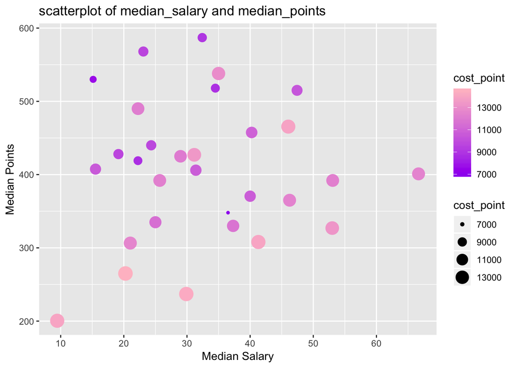

```r
ggplot(points_salary1) +
  geom_point(aes(x = median_salary, y = median_points, size = cost_point, color = cost_point)) +
  labs(title = "scatterplot of median_salary and median_points") +
  xlab("Median Salary") +
  ylab("Median Points") +
  scale_color_gradient(low = "purple", high = "pink")
```